# 《R + Amos + SPSS》

王超

15-02-2026

# 1 潜在剖面分析(LPA)

**Latent Profile Analysis (LPA)** is a statistical method used to identify unobserved subgroups or latent classes within a population based on individuals’ responses to multiple observed variables. It is a type of mixture modeling, specifically suited for continuous data, and belongs to the broader family of latent variable models.

Key Concepts of LPA:

- Latent Variables: These are variables that cannot be directly measured but are inferred from observed data. In LPA, latent variables represent the unobserved profiles or subgroups in the population that individuals belong to.
- Latent Profiles/Classes: LPA aims to classify individuals into latent profiles, or subgroups, based on their response patterns across observed variables. Each latent profile is characterized by a distinct pattern of values across the observed indicators.
- Observed Variables: These are the measured variables used in the analysis. In LPA, observed variables are typically continuous (e.g., psychological traits, behavioral scores, or survey responses).

Steps in LPA:

- Selection of Observed Variables: Researchers choose a set of observed variables that are relevant to the research question and are assumed to be indicators of the latent profiles.
- Model Specification: The number of latent profiles (i.e., the number of subgroups or clusters) is determined, often using model fit indices such as Akaike Information Criterion (AIC), Bayesian Information Criterion (BIC), and other criteria.
- Model Estimation: LPA models are typically estimated using maximum likelihood estimation (MLE), which estimates the probability that each individual belongs to each latent profile.
- Interpretation of Profiles: After identifying the latent profiles, researchers interpret each profile based on its mean or pattern of observed variables. This helps to characterize the distinct subgroups or patterns in the population.
- Model Evaluation: The model’s fit and validity are assessed using various fit indices and potentially external validation (such as cross-validation or external datasets).

【参考文献:短视频成瘾的潜在剖面分析】

LPA-案例数据集:mtcars((mpg, hp, wt, qsec)

```
## 案例数据结构：数值型
## 'data.frame':    32 obs. of  4 variables:
##  $ mpg : num  21 21 22.8 21.4 18.7 18.1 14.3 24.4 22.8 19.2 ...
##  $ hp  : num  110 110 93 110 175 105 245 62 95 123 ...
##  $ wt  : num  2.62 2.88 2.32 3.21 3.44 ...
##  $ qsec: num  16.5 17 18.6 19.4 17 ...
```

LPA-剖面分析并显示结果

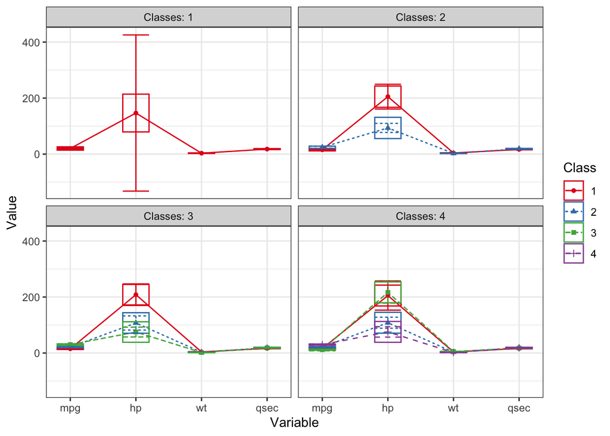

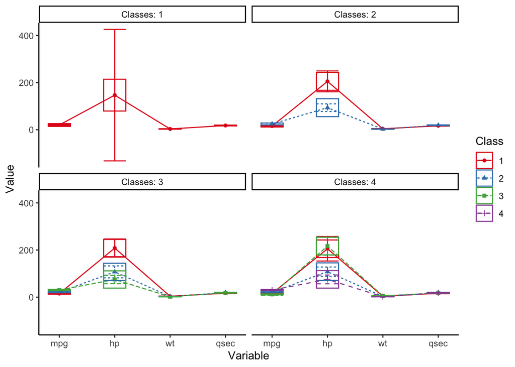

```
## tidyLPA analysis using mclust:
##
##  Model Classes AIC    BIC    Entropy prob_min prob_max n_min n_max BLRT_p
##  1     1       796.48 808.20 1.00    1.00     1.00     1.00  1.00
##  1     2       749.80 768.85 0.92    0.98     0.99     0.47  0.53  0.01
##  1     3       734.57 760.95 0.92    0.92     1.00     0.19  0.47  0.01
##  1     4       710.04 743.76 0.96    0.96     1.00     0.09  0.38  0.01
```

LPA-提取指定剖面的分类序号

```
##           Mazda RX4       Mazda RX4 Wag          Datsun 710      Hornet 4 Drive
##                   2                   2                   2                   2
##   Hornet Sportabout             Valiant          Duster 360           Merc 240D
##                   1                   2                   1                   2
##            Merc 230            Merc 280           Merc 280C          Merc 450SE
##                   2                   2                   2                   1
##          Merc 450SL         Merc 450SLC  Cadillac Fleetwood Lincoln Continental
##                   1                   1                   1                   1
##   Chrysler Imperial            Fiat 128         Honda Civic      Toyota Corolla
##                   1                   2                   2                   2
##       Toyota Corona    Dodge Challenger         AMC Javelin          Camaro Z28
##                   2                   1                   1                   1
##    Pontiac Firebird           Fiat X1-9       Porsche 914-2        Lotus Europa
##                   1                   2                   2                   2
##      Ford Pantera L        Ferrari Dino       Maserati Bora          Volvo 142E
##                   1                   1                   1                   2
```

LPA-添加分类序号到数据集，查看并可视化

```
##                    mpg  hp    wt  qsec Class
## Mazda RX4         21.0 110 2.620 16.46     2
## Mazda RX4 Wag     21.0 110 2.875 17.02     2
## Datsun 710        22.8  93 2.320 18.61     2
## Hornet 4 Drive    21.4 110 3.215 19.44     2
## Hornet Sportabout 18.7 175 3.440 17.02     1
## Valiant           18.1 105 3.460 20.22     2
```

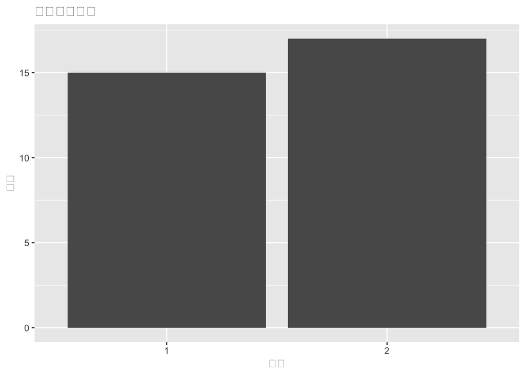

LPA-查看指定剖面各变量中心值、分组计算并可视化

```
##            [,1]      [,2]
## mpg   15.470226 24.299413
## hp   205.160620 93.423494
## wt     3.908598  2.587492
## qsec  16.730934 18.866984
## # A tibble: 2 × 5
##   Class   mpg    hp    wt  qsec
##   <fct> <dbl> <dbl> <dbl> <dbl>
## 1 1      15.4 207.   3.92  16.7
## 2 2      24.2  93.5  2.60  18.9
```

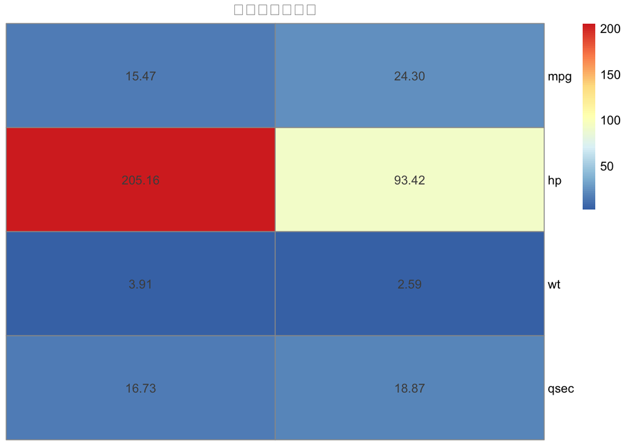